# LBB 7

Ambiya Sang Aji

May 31, 2019

# LBB - Unsupervised Learning

Dalam laporan ini, data yang digunakan adalah data customer credit card. data diambil dari website kaggle, akan dicoba untuk melakukan clustering dengan menggunakan algoritma k-means, dan dibandingkan dengan menggunakan algoritma k-means + PCA preprocessing untuk mencari segmentasi customer.

Deskripsi dari field data yang akan digunakan adalah :

CUST_ID : Identification of Credit Card holder (Categorical) BALANCE : Balance amount left in their account to make purchases BALANCE_FREQUENCY : How frequently the Balance is updated, score between 0 and 1 (1 = frequently updated, 0 = not frequently updated) PURCHASES : Amount of purchases made from account ONEOFF_PURCHASES : Maximum purchase amount done in one-go INSTALLMENTS_PURCHASES : Amount of purchase done in installment CASH_ADVANCE : Cash in advance given by the user PURCHASES_FREQUENCY : How frequently the Purchases are being made, score between 0 and 1 (1 = frequently purchased, 0 = not frequently purchased) ONEOFFPURCHASESFREQUENCY : How frequently Purchases are happening in one-go (1 = frequently purchased, 0 = not frequently purchased) PURCHASESINSTALLMENTSFREQUENCY : How frequently purchases in installments are being done (1 = frequently done, 0 = not frequently done) CASHADVANCEFREQUENCY : How frequently the cash in advance being paid CASHADVANCETRX : Number of Transactions made with “Cash in Advanced” PURCHASES_TRX : Number of purchase transactions made CREDIT_LIMIT : Limit of Credit Card for user PAYMENTS : Amount of Payment done by user MINIMUM_PAYMENTS : Minimum amount of payments made by user PRCFULLPAYMENT : Percent of full payment paid by user TENURE : Tenure of credit card service for user

Akan dilakukan pengecekan terhadap data terlebih dahulu

# Read and Analyze Data

```r
cc <- read.csv("CC GENERAL.csv")
head(cc)
```

|  | CUST_ID | BALANCE | BALANCE_FREQUENCY | PURCHASES | ONEOFF_PURCHASES | INSTALLMENTS_PURCHASES | CASH_ADVANCE | PURCHASES_FREQUENCY | ONEOFF_PURCHASES_FREQUENCY | PURCHASES_INSTALLMENTS_FREQUENCY | CASH_ADVANCE_FREQUENCY | CASH_ADVANCE_TRX | PURCHASES_TRX | CREDIT_LIMIT | PAYMENTS | MINIMUM_PAYMENTS | PRC_FULL_PAYMENT | TENURE |
| --- | --- | --- | --- | --- | --- | --- | --- | --- | --- | --- | --- | --- | --- | --- | --- | --- | --- | --- |
| 1 | C10001 | 40.90075 | 0.818182 | 95.40 | 0.00 | 95.40 | 0.000 | 0.166667 | 0.000000 | 0.083333 | 0.000000 | 0 | 2 | 1000 | 201.8021 | 139.5098 | 0.000000 | 12 |
| 2 | C10002 | 3202.46742 | 0.909091 | 0.00 | 0.00 | 0.00 | 6442.945 | 0.000000 | 0.000000 | 0.000000 | 0.250000 | 4 | 0 | 7000 | 4103.0326 | 1072.3402 | 0.222222 | 12 |
| 3 | C10003 | 2495.14886 | 1.000000 | 773.17 | 773.17 | 0.00 | 0.000 | 1.000000 | 1.000000 | 0.000000 | 0.000000 | 0 | 12 | 7500 | 622.0667 | 627.2848 | 0.000000 | 12 |
| 4 | C10004 | 1666.67054 | 0.636364 | 1499.00 | 1499.00 | 0.00 | 205.788 | 0.083333 | 0.083333 | 0.000000 | 0.083333 | 1 | 1 | 7500 | 0.0000 | NA | 0.000000 | 12 |
| 5 | C10005 | 817.71434 | 1.000000 | 16.00 | 16.00 | 0.00 | 0.000 | 0.083333 | 0.083333 | 0.000000 | 0.000000 | 0 | 1 | 1200 | 678.3348 | 244.7912 | 0.000000 | 12 |
| 6 | C10006 | 1809.82875 | 1.000000 | 1333.28 | 0.00 | 1333.28 | 0.000 | 0.666667 | 0.000000 | 0.583333 | 0.000000 | 0 | 8 | 1800 | 1400.0578 | 2407.2460 | 0.000000 | 12 |

Column 1 akan dihapus karena column tersebut hanya berisi ID

jika dilihat banyak data yang nilai nya 0, namun secara deskripsi dari field di data, angka 0 disini bukanlah missing value, selanjutnya akan dilakukan perhitungan missing value untuk seluruh column

```r
cc <- cc[,-1]
countnull<-matrix(data=NA,ncol=ncol(cc),nrow=1)
for (i in 1:ncol(cc)) {
countnull[1,i] <- sum(is.na(cc[,i]))
}
countnull
```

```
##      [,1] [,2] [,3] [,4] [,5] [,6] [,7] [,8] [,9] [,10] [,11] [,12] [,13]
## [1,]    0    0    0    0    0    0    0    0    0     0     0     0     1
##      [,14] [,15] [,16] [,17]
## [1,]     0   313     0     0
```

```r
cc <- na.omit(cc)
```

Akan dilakukan pengecekan atribut tipe data

```r
str(cc)
```

```
## 'data.frame':    8636 obs. of  17 variables:
##  $ BALANCE                         : num  40.9 3202.5 2495.1 817.7 1809.8 ...
##  $ BALANCE_FREQUENCY               : num  0.818 0.909 1 1 1 ...
##  $ PURCHASES                       : num  95.4 0 773.2 16 1333.3 ...
##  $ ONEOFF_PURCHASES                : num  0 0 773 16 0 ...
##  $ INSTALLMENTS_PURCHASES          : num  95.4 0 0 0 1333.3 ...
##  $ CASH_ADVANCE                    : num  0 6443 0 0 0 ...
##  $ PURCHASES_FREQUENCY             : num  0.1667 0 1 0.0833 0.6667 ...
##  $ ONEOFF_PURCHASES_FREQUENCY      : num  0 0 1 0.0833 0 ...
##  $ PURCHASES_INSTALLMENTS_FREQUENCY: num  0.0833 0 0 0 0.5833 ...
##  $ CASH_ADVANCE_FREQUENCY          : num  0 0.25 0 0 0 0 0 0 0 0 ...
##  $ CASH_ADVANCE_TRX                : int  0 4 0 0 0 0 0 0 0 0 ...
##  $ PURCHASES_TRX                   : int  2 0 12 1 8 64 12 5 3 12 ...
##  $ CREDIT_LIMIT                    : num  1000 7000 7500 1200 1800 13500 2300 7000 11000 1200 ...
##  $ PAYMENTS                        : num  202 4103 622 678 1400 ...
##  $ MINIMUM_PAYMENTS                : num  140 1072 627 245 2407 ...
##  $ PRC_FULL_PAYMENT                : num  0 0.222 0 0 0 ...
##  $ TENURE                          : int  12 12 12 12 12 12 12 12 12 12 ...
##  - attr(*, "na.action")= 'omit' Named int  4 46 48 55 56 57 64 94 95 98 ...
##   ..- attr(*, "names")= chr  "4" "46" "48" "55" ...
```

Tipe data dari seluruh field sudah menggunakan numeric dan integer, data ini sudah aman untuk dilakukan clustering.

Sebelum melakukan clustering, akan dibuat satu variabel yang menampung data yang dilakukan scaling terlebih dahulu

```r
cc_s <- scale(cc)
```

# Cluseting Menggunakan K-Means

Data telah dilakukan pengecekan dan preprocessing, selanjutnya akan dilakukan clustering dengan hanya menggunakan algoritma k-means. akan dilakukan pengecekan set terbaik dengan mengecek wss terkecil dan k-terbaik menggunakan metode elbow point

```r
countwss<-matrix(data=NA,ncol=2,nrow=20)
x <- 1
for (i in seq(10, 200, by = 10))  {
      set.seed(i)
      countwss[x,1] <- i
      countwss[x,2] <- sum(kmeans(cc_s, 3)$withinss)
      x <- x+1
}
apply(countwss,2,sort)
```

```
##       [,1]     [,2]
##  [1,]   10 108073.7
##  [2,]   20 108073.7
##  [3,]   30 108073.7
##  [4,]   40 108073.7
##  [5,]   50 108597.6
##  [6,]   60 108597.6
##  [7,]   70 108598.6
##  [8,]   80 108599.1
##  [9,]   90 108599.1
## [10,]  100 108603.6
## [11,]  110 108603.6
## [12,]  120 108603.6
## [13,]  130 108603.6
## [14,]  140 108754.0
## [15,]  150 108754.0
## [16,]  160 108754.0
## [17,]  170 108754.0
## [18,]  180 108754.0
## [19,]  190 108754.0
## [20,]  200 108754.0
```

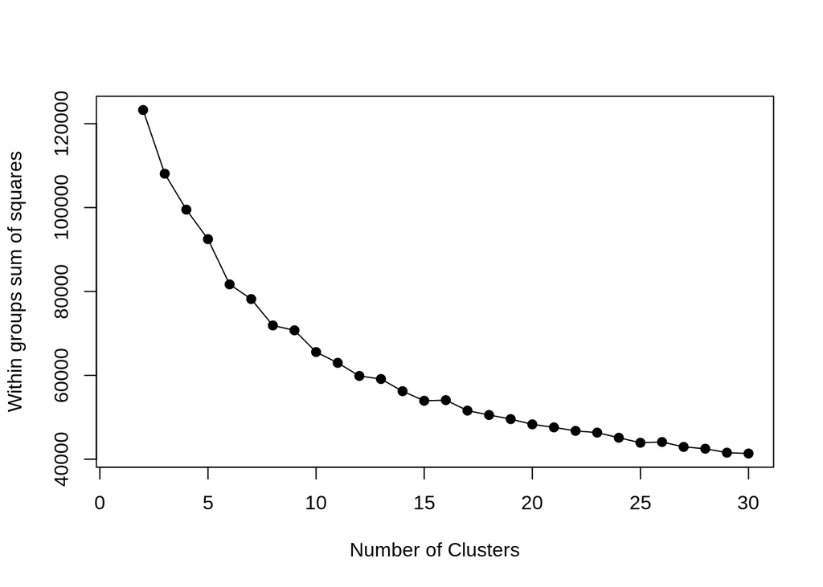

```r
wss <- function(data, maxCluster = 30) {
    # Initialize within sum of squares
    SSw <- (nrow(data) - 1) * sum(apply(data, 2, var))
    SSw <- vector()
    set.seed(30)
    for (i in 2:maxCluster) {
        SSw[i] <- sum(kmeans(data, centers = i)$withinss)
    }
    plot(1:maxCluster, SSw, type = "o", xlab = "Number of Clusters", ylab = "Within groups sum of squares", pch=19)
}
wss(cc_s)
```

Berdasarkan pengamatan, nilai cluster yang paling baik adalah di angka 8, dikarenakan jika nilai k > 8, menghasilkan penurunan dari steep yang cukup signifikan. yang berarti penurunan nilai wssnya juga tidak signifikan.

Melakukan proses cluster dengan nilai k = 8

```r
set.seed(30)
clus_cc <- kmeans(cc_s, 8)
#assign cluster ke column baru di data awal
cc$clust <- as.factor(clus_cc$cluster)
```

# Plot cluster using PCA as tools

Akan dilakukan visualisasi dari data dengan menggunakan bantuan PCA dan membuat biplot untuk dapat memberi bantuan melakukan analisa terhadap data

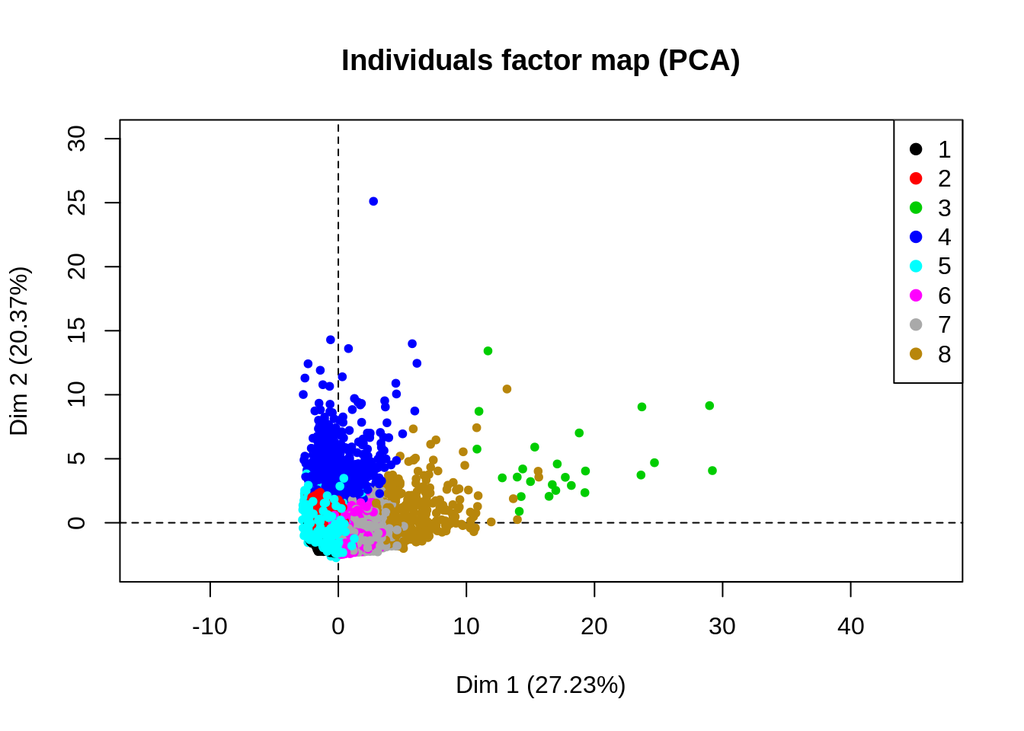

```r
# creates biplots
cc_s.pca<-PCA(cc_s, graph = F)
plot(cc_s.pca, choix=c("ind"), label="none", col.ind=cc$clust)
legend("topright", levels(cc$clust), pch=19, col=1:8)
```

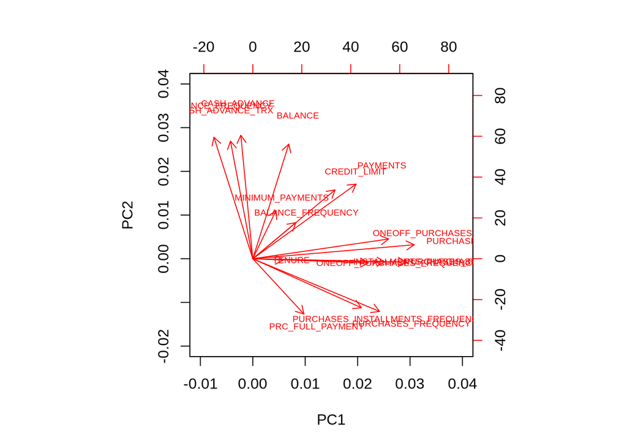

```r
biplot(prcomp(cc_s, scale=F), cex=0.6, xlim = c(-0.01, 0.04), ylim = c(-0.02, 0.04), xlabs=rep("", nrow(cc_s)))
```

# Summary Cluster

Akan dilakukan summary dari masing-masing cluster untuk melakukan analisa terhadap cluster dengan bantuan plot

```r
summary(cc[cc$clust==1,])
```

```
##     BALANCE        BALANCE_FREQUENCY   PURCHASES      ONEOFF_PURCHASES
##  Min.   :   0.00   Min.   :0.0000    Min.   :   0.0   Min.   :   0.0
##  1st Qu.:  10.31   1st Qu.:0.2727    1st Qu.:  56.2   1st Qu.:   0.0
##  Median :  31.93   Median :0.4545    Median : 192.2   Median :   0.0
##  Mean   : 135.07   Mean   :0.4298    Mean   : 371.4   Mean   : 219.4
##  3rd Qu.: 113.87   3rd Qu.:0.5455    3rd Qu.: 484.6   3rd Qu.: 236.5
##  Max.   :2953.21   Max.   :0.8182    Max.   :3734.7   Max.   :3734.7
##
##  INSTALLMENTS_PURCHASES  CASH_ADVANCE    PURCHASES_FREQUENCY
##  Min.   :   0.0         Min.   :   0.0   Min.   :0.00000
##  1st Qu.:   0.0         1st Qu.:   0.0   1st Qu.:0.08333
##  Median :  24.9         Median :   0.0   Median :0.25000
##  Mean   : 152.3         Mean   : 329.2   Mean   :0.27214
##  3rd Qu.: 213.6         3rd Qu.:   0.0   3rd Qu.:0.41667
##  Max.   :3011.4         Max.   :7378.3   Max.   :1.00000
##
##  ONEOFF_PURCHASES_FREQUENCY PURCHASES_INSTALLMENTS_FREQUENCY
##  Min.   :0.00000            Min.   :0.00000
##  1st Qu.:0.00000            1st Qu.:0.00000
##  Median :0.00000            Median :0.08333
##  Mean   :0.07855            Mean   :0.18595
##  3rd Qu.:0.08333            3rd Qu.:0.33333
##  Max.   :0.91667            Max.   :1.00000
##
##  CASH_ADVANCE_FREQUENCY CASH_ADVANCE_TRX  PURCHASES_TRX     CREDIT_LIMIT
##  Min.   :0.00000        Min.   : 0.0000   Min.   : 0.000   Min.   :  300
##  1st Qu.:0.00000        1st Qu.: 0.0000   1st Qu.: 1.000   1st Qu.: 1500
##  Median :0.00000        Median : 0.0000   Median : 3.000   Median : 3000
##  Mean   :0.03368        Mean   : 0.7274   Mean   : 4.503   Mean   : 3902
##  3rd Qu.:0.00000        3rd Qu.: 0.0000   3rd Qu.: 6.500   3rd Qu.: 5000
##  Max.   :0.41667        Max.   :24.0000   Max.   :31.000   Max.   :23000
##
##     PAYMENTS        MINIMUM_PAYMENTS    PRC_FULL_PAYMENT      TENURE
##  Min.   :    0.06   Min.   :   0.0192   Min.   :0.00000   Min.   : 8.00
##  1st Qu.:  235.88   1st Qu.:  73.6003   1st Qu.:0.00000   1st Qu.:12.00
##  Median :  515.84   Median : 121.7812   Median :0.09091   Median :12.00
##  Mean   : 1328.48   Mean   : 162.9120   Mean   :0.27946   Mean   :11.81
##  3rd Qu.: 1295.74   3rd Qu.: 167.2355   3rd Qu.:0.50000   3rd Qu.:12.00
##  Max.   :34107.07   Max.   :3116.6791   Max.   :1.00000   Max.   :12.00
##
##      clust
##  1      :1071
##  2      :   0
##  3      :   0
##  4      :   0
##  5      :   0
##  6      :   0
##  (Other):   0
```

```r
summary(cc[cc$clust==2,])
```

```
##     BALANCE         BALANCE_FREQUENCY   PURCHASES       ONEOFF_PURCHASES
##  Min.   :   0.488   Min.   :0.5455    Min.   :   0.00   Min.   :   0.0
##  1st Qu.: 713.782   1st Qu.:1.0000    1st Qu.:   0.00   1st Qu.:   0.0
##  Median :1271.212   Median :1.0000    Median :  45.65   Median :   0.0
##  Mean   :1602.422   Mean   :0.9763    Mean   : 241.26   Mean   : 190.6
##  3rd Qu.:2115.904   3rd Qu.:1.0000    3rd Qu.: 302.20   3rd Qu.: 201.1
##  Max.   :9335.314   Max.   :1.0000    Max.   :4900.00   Max.   :4900.0
##
##  INSTALLMENTS_PURCHASES  CASH_ADVANCE    PURCHASES_FREQUENCY
##  Min.   :   0.00        Min.   :   0.0   Min.   :0.00000
##  1st Qu.:   0.00        1st Qu.:   0.0   1st Qu.:0.00000
##  Median :   0.00        Median : 299.9   Median :0.08333
##  Mean   :  50.86        Mean   : 782.9   Mean   :0.14964
##  3rd Qu.:   0.00        3rd Qu.:1238.1   3rd Qu.:0.25000
##  Max.   :3000.00        Max.   :6322.8   Max.   :0.75000
##
##  ONEOFF_PURCHASES_FREQUENCY PURCHASES_INSTALLMENTS_FREQUENCY
##  Min.   :0.00000            Min.   :0.00000
##  1st Qu.:0.00000            1st Qu.:0.00000
##  Median :0.00000            Median :0.00000
##  Mean   :0.08499            Mean   :0.06605
##  3rd Qu.:0.09091            3rd Qu.:0.00000
##  Max.   :0.75000            Max.   :0.66667
##
##  CASH_ADVANCE_FREQUENCY CASH_ADVANCE_TRX PURCHASES_TRX     CREDIT_LIMIT
##  Min.   :0.00000        Min.   : 0.000   Min.   : 0.000   Min.   :   50
##  1st Qu.:0.00000        1st Qu.: 0.000   1st Qu.: 0.000   1st Qu.: 1500
##  Median :0.09091        Median : 2.000   Median : 1.000   Median : 2500
##  Mean   :0.15733        Mean   : 3.091   Mean   : 2.789   Mean   : 3383
##  3rd Qu.:0.25000        3rd Qu.: 5.000   3rd Qu.: 4.000   3rd Qu.: 4500
##  Max.   :0.90000        Max.   :31.000   Max.   :43.000   Max.   :16500
##
##     PAYMENTS      MINIMUM_PAYMENTS    PRC_FULL_PAYMENT      TENURE
##  Min.   :  14.5   Min.   :    5.038   Min.   :0.00000   Min.   : 9.00
##  1st Qu.: 383.4   1st Qu.:  257.052   1st Qu.:0.00000   1st Qu.:12.00
##  Median : 658.6   Median :  443.646   Median :0.00000   Median :12.00
##  Mean   :1030.0   Mean   :  841.947   Mean   :0.02118   Mean   :11.88
##  3rd Qu.:1226.8   3rd Qu.:  784.403   3rd Qu.:0.00000   3rd Qu.:12.00
##  Max.   :9614.7   Max.   :28483.255   Max.   :1.00000   Max.   :12.00
##
##      clust
##  2      :2695
##  1      :   0
##  3      :   0
##  4      :   0
##  5      :   0
##  6      :   0
##  (Other):   0
```

```r
summary(cc[cc$clust==3,])
```

```
##     BALANCE      BALANCE_FREQUENCY   PURCHASES     ONEOFF_PURCHASES
##  Min.   : 1269   Min.   :0.2727    Min.   :12552   Min.   : 9449
##  1st Qu.: 2742   1st Qu.:1.0000    1st Qu.:21958   1st Qu.:15636
##  Median : 3423   Median :1.0000    Median :26009   Median :21224
##  Mean   : 5405   Mean   :0.9580    Mean   :27276   Mean   :21877
##  3rd Qu.: 6817   3rd Qu.:1.0000    3rd Qu.:31609   3rd Qu.:25471
##  Max.   :19043   Max.   :1.0000    Max.   :49040   Max.   :40761
##
##  INSTALLMENTS_PURCHASES  CASH_ADVANCE   PURCHASES_FREQUENCY
##  Min.   :    0.0        Min.   :    0   Min.   :0.1667
##  1st Qu.:  905.6        1st Qu.:    0   1st Qu.:1.0000
##  Median : 4828.5        Median :    0   Median :1.0000
##  Mean   : 5399.3        Mean   : 1550   Mean   :0.9090
##  3rd Qu.: 7874.8        3rd Qu.:    0   3rd Qu.:1.0000
##  Max.   :15497.2        Max.   :19513   Max.   :1.0000
##
##  ONEOFF_PURCHASES_FREQUENCY PURCHASES_INSTALLMENTS_FREQUENCY
##  Min.   :0.1667             Min.   :0.0000
##  1st Qu.:0.6667             1st Qu.:0.5417
##  Median :1.0000             Median :0.9167
##  Mean   :0.8424             Mean   :0.7208
##  3rd Qu.:1.0000             3rd Qu.:1.0000
##  Max.   :1.0000             Max.   :1.0000
##
##  CASH_ADVANCE_FREQUENCY CASH_ADVANCE_TRX PURCHASES_TRX    CREDIT_LIMIT
##  Min.   :0.00000        Min.   : 0.0     Min.   :  3.0   Min.   : 7500
##  1st Qu.:0.00000        1st Qu.: 0.0     1st Qu.: 71.5   1st Qu.:12000
##  Median :0.00000        Median : 0.0     Median :107.5   Median :17000
##  Mean   :0.05903        Mean   : 2.5     Mean   :128.0   Mean   :16083
##  3rd Qu.:0.00000        3rd Qu.: 0.0     3rd Qu.:161.5   3rd Qu.:18000
##  Max.   :0.66667        Max.   :35.0     Max.   :358.0   Max.   :30000
##
##     PAYMENTS     MINIMUM_PAYMENTS  PRC_FULL_PAYMENT      TENURE
##  Min.   :13002   Min.   :  410.8   Min.   :0.00000   Min.   :10.00
##  1st Qu.:22495   1st Qu.:  567.8   1st Qu.:0.08333   1st Qu.:12.00
##  Median :26605   Median : 1171.4   Median :0.50000   Median :12.00
##  Mean   :27926   Mean   : 3266.7   Mean   :0.51121   Mean   :11.92
##  3rd Qu.:32272   3rd Qu.: 2790.4   3rd Qu.:0.93750   3rd Qu.:12.00
##  Max.   :50721   Max.   :18621.0   Max.   :1.00000   Max.   :12.00
##
##      clust
##  3      :24
##  1      : 0
##  2      : 0
##  4      : 0
##  5      : 0
##  6      : 0
##  (Other): 0
```

```r
summary(cc[cc$clust==4,])
```

```
##     BALANCE         BALANCE_FREQUENCY   PURCHASES      ONEOFF_PURCHASES
##  Min.   :   78.11   Min.   :0.3636    Min.   :   0.0   Min.   :   0.0
##  1st Qu.: 2938.39   1st Qu.:1.0000    1st Qu.:   0.0   1st Qu.:   0.0
##  Median : 4947.61   Median :1.0000    Median : 133.5   Median :   0.0
##  Mean   : 5135.94   Mean   :0.9737    Mean   : 548.9   Mean   : 338.8
##  3rd Qu.: 6853.78   3rd Qu.:1.0000    3rd Qu.: 718.6   3rd Qu.: 361.1
##  Max.   :16304.89   Max.   :1.0000    Max.   :7194.5   Max.   :6678.3
##
##  INSTALLMENTS_PURCHASES  CASH_ADVANCE   PURCHASES_FREQUENCY
##  Min.   :   0.0         Min.   :    0   Min.   :0.00000
##  1st Qu.:   0.0         1st Qu.: 2812   1st Qu.:0.00000
##  Median :   0.0         Median : 4263   Median :0.09091
##  Mean   : 210.2         Mean   : 5203   Mean   :0.30689
##  3rd Qu.: 201.2         3rd Qu.: 6396   3rd Qu.:0.58333
##  Max.   :3887.0         Max.   :47137   Max.   :1.00000
##
##  ONEOFF_PURCHASES_FREQUENCY PURCHASES_INSTALLMENTS_FREQUENCY
##  Min.   :0.0000             Min.   :0.0000
##  1st Qu.:0.0000             1st Qu.:0.0000
##  Median :0.0000             Median :0.0000
##  Mean   :0.1424             Mean   :0.2053
##  3rd Qu.:0.1818             3rd Qu.:0.3409
##  Max.   :1.0000             Max.   :1.0000
##
##  CASH_ADVANCE_FREQUENCY CASH_ADVANCE_TRX PURCHASES_TRX     CREDIT_LIMIT
##  Min.   :0.0000         Min.   :  0.0    Min.   : 0.000   Min.   : 1000
##  1st Qu.:0.3333         1st Qu.:  9.0    1st Qu.: 0.000   1st Qu.: 6000
##  Median :0.5000         Median : 13.0    Median : 2.000   Median : 8000
##  Mean   :0.5182         Mean   : 16.5    Mean   : 8.249   Mean   : 8330
##  3rd Qu.:0.6667         3rd Qu.: 21.0    3rd Qu.:11.000   3rd Qu.:10500
##  Max.   :1.5000         Max.   :123.0    Max.   :94.000   Max.   :21500
##
##     PAYMENTS        MINIMUM_PAYMENTS   PRC_FULL_PAYMENT      TENURE
##  Min.   :   46.97   Min.   :   16.95   Min.   :0.00000   Min.   : 6.00
##  1st Qu.: 1393.89   1st Qu.:  920.04   1st Qu.:0.00000   1st Qu.:12.00
##  Median : 2335.81   Median : 1486.01   Median :0.00000   Median :12.00
##  Mean   : 4084.99   Mean   : 2181.30   Mean   :0.03725   Mean   :11.63
##  3rd Qu.: 5150.69   3rd Qu.: 2276.60   3rd Qu.:0.00000   3rd Qu.:12.00
##  Max.   :39048.60   Max.   :61031.62   Max.   :0.91667   Max.   :12.00
##
##      clust
##  4      :852
##  1      :  0
##  2      :  0
##  3      :  0
##  5      :  0
##  6      :  0
##  (Other):  0
```

```r
summary(cc[cc$clust==5,])
```

```
##     BALANCE         BALANCE_FREQUENCY   PURCHASES      ONEOFF_PURCHASES
##  Min.   :   0.272   Min.   :0.1250    Min.   :   0.0   Min.   :   0.0
##  1st Qu.:  91.894   1st Qu.:0.7143    1st Qu.:   0.0   1st Qu.:   0.0
##  Median : 624.718   Median :0.8750    Median : 176.0   Median :   0.0
##  Mean   : 913.290   Mean   :0.8280    Mean   : 397.4   Mean   : 236.0
##  3rd Qu.:1250.432   3rd Qu.:1.0000    3rd Qu.: 528.4   3rd Qu.: 190.5
##  Max.   :7215.196   Max.   :1.0000    Max.   :4139.6   Max.   :4139.6
##
##  INSTALLMENTS_PURCHASES  CASH_ADVANCE     PURCHASES_FREQUENCY
##  Min.   :   0.0         Min.   :    0.0   Min.   :0.0000
##  1st Qu.:   0.0         1st Qu.:    0.0   1st Qu.:0.0000
##  Median :   0.0         Median :  530.2   Median :0.3333
##  Mean   : 161.9         Mean   : 1172.2   Mean   :0.4252
##  3rd Qu.: 218.1         3rd Qu.: 1819.0   3rd Qu.:0.8333
##  Max.   :2068.2         Max.   :10590.4   Max.   :1.0000
##
##  ONEOFF_PURCHASES_FREQUENCY PURCHASES_INSTALLMENTS_FREQUENCY
##  Min.   :0.0000             Min.   :0.0000
##  1st Qu.:0.0000             1st Qu.:0.0000
##  Median :0.0000             Median :0.0000
##  Mean   :0.1184             Mean   :0.2886
##  3rd Qu.:0.1429             3rd Qu.:0.6667
##  Max.   :1.0000             Max.   :1.0000
##
##  CASH_ADVANCE_FREQUENCY CASH_ADVANCE_TRX PURCHASES_TRX     CREDIT_LIMIT
##  Min.   :0.0000         Min.   : 0.000   Min.   : 0.000   Min.   :  300
##  1st Qu.:0.0000         1st Qu.: 0.000   1st Qu.: 0.000   1st Qu.: 1200
##  Median :0.1429         Median : 2.000   Median : 3.000   Median : 1500
##  Mean   :0.2037         Mean   : 3.298   Mean   : 5.303   Mean   : 2465
##  3rd Qu.:0.3333         3rd Qu.: 5.000   3rd Qu.: 7.000   3rd Qu.: 3000
##  Max.   :1.1667         Max.   :26.000   Max.   :54.000   Max.   :14000
##
##     PAYMENTS        MINIMUM_PAYMENTS   PRC_FULL_PAYMENT     TENURE
##  Min.   :    0.05   Min.   :   1.519   Min.   :0.0000   Min.   : 6.000
##  1st Qu.:  166.55   1st Qu.:  96.237   1st Qu.:0.0000   1st Qu.: 6.000
##  Median :  313.88   Median : 165.054   Median :0.0000   Median : 7.000
##  Mean   :  672.74   Mean   : 346.505   Mean   :0.1656   Mean   : 7.279
##  3rd Qu.:  659.39   3rd Qu.: 371.631   3rd Qu.:0.2000   3rd Qu.: 8.000
##  Max.   :19998.39   Max.   :7243.733   Max.   :1.0000   Max.   :10.000
##
##      clust
##  5      :591
##  1      :  0
##  2      :  0
##  3      :  0
##  4      :  0
##  6      :  0
##  (Other):  0
```

```r
summary(cc[cc$clust==6,])
```

```
##     BALANCE         BALANCE_FREQUENCY   PURCHASES      ONEOFF_PURCHASES
##  Min.   :   1.632   Min.   :0.3636    Min.   :  12.0   Min.   :   0.0
##  1st Qu.:  69.796   1st Qu.:1.0000    1st Qu.: 379.8   1st Qu.:   0.0
##  Median : 300.411   Median :1.0000    Median : 670.3   Median :   0.0
##  Mean   : 827.820   Mean   :0.9624    Mean   : 936.2   Mean   : 191.2
##  3rd Qu.:1196.315   3rd Qu.:1.0000    3rd Qu.:1282.6   3rd Qu.: 225.0
##  Max.   :7994.332   Max.   :1.0000    Max.   :4709.1   Max.   :3227.8
##
##  INSTALLMENTS_PURCHASES  CASH_ADVANCE    PURCHASES_FREQUENCY
##  Min.   :  12.0         Min.   :   0.0   Min.   :0.4167
##  1st Qu.: 316.8         1st Qu.:   0.0   1st Qu.:0.8333
##  Median : 537.6         Median :   0.0   Median :1.0000
##  Mean   : 745.5         Mean   : 217.2   Mean   :0.8933
##  3rd Qu.: 980.3         3rd Qu.:   0.0   3rd Qu.:1.0000
##  Max.   :4313.2         Max.   :5903.8   Max.   :1.0000
##
##  ONEOFF_PURCHASES_FREQUENCY PURCHASES_INSTALLMENTS_FREQUENCY
##  Min.   :0.00000            Min.   :0.2500
##  1st Qu.:0.00000            1st Qu.:0.7500
##  Median :0.00000            Median :0.9167
##  Mean   :0.08874            Mean   :0.8488
##  3rd Qu.:0.16667            3rd Qu.:1.0000
##  Max.   :0.58333            Max.   :1.0000
##
##  CASH_ADVANCE_FREQUENCY CASH_ADVANCE_TRX  PURCHASES_TRX     CREDIT_LIMIT
##  Min.   :0.00000        Min.   : 0.0000   Min.   :  0.00   Min.   :  400
##  1st Qu.:0.00000        1st Qu.: 0.0000   1st Qu.: 12.00   1st Qu.: 1500
##  Median :0.00000        Median : 0.0000   Median : 14.00   Median : 2500
##  Mean   :0.04079        Mean   : 0.7978   Mean   : 19.69   Mean   : 3544
##  3rd Qu.:0.00000        3rd Qu.: 0.0000   3rd Qu.: 24.00   3rd Qu.: 5000
##  Max.   :0.66667        Max.   :16.0000   Max.   :111.00   Max.   :19500
##
##     PAYMENTS      MINIMUM_PAYMENTS   PRC_FULL_PAYMENT     TENURE
##  Min.   :  29.9   Min.   :    0.26   Min.   :0.0000   Min.   : 8.00
##  1st Qu.: 408.7   1st Qu.:  162.75   1st Qu.:0.0000   1st Qu.:12.00
##  Median : 774.6   Median :  194.39   Median :0.0000   Median :12.00
##  Mean   :1114.9   Mean   :  806.82   Mean   :0.2453   Mean   :11.87
##  3rd Qu.:1453.5   3rd Qu.:  620.05   3rd Qu.:0.4444   3rd Qu.:12.00
##  Max.   :9000.7   Max.   :38512.12   Max.   :1.0000   Max.   :12.00
##
##      clust
##  6      :1958
##  1      :   0
##  2      :   0
##  3      :   0
##  4      :   0
##  5      :   0
##  (Other):   0
```

```r
summary(cc[cc$clust==7,])
```

```
##     BALANCE         BALANCE_FREQUENCY   PURCHASES      ONEOFF_PURCHASES
##  Min.   :   1.198   Min.   :0.1818    Min.   :   8.4   Min.   :   8.4
##  1st Qu.: 222.322   1st Qu.:1.0000    1st Qu.:1120.3   1st Qu.: 815.1
##  Median : 635.482   Median :1.0000    Median :1937.7   Median :1380.0
##  Mean   :1277.135   Mean   :0.9737    Mean   :2176.8   Mean   :1718.1
##  3rd Qu.:1838.107   3rd Qu.:1.0000    3rd Qu.:2894.0   3rd Qu.:2236.7
##  Max.   :8978.156   Max.   :1.0000    Max.   :9661.4   Max.   :9661.4
##
##  INSTALLMENTS_PURCHASES  CASH_ADVANCE     PURCHASES_FREQUENCY
##  Min.   :   0.0         Min.   :   0.00   Min.   :0.2500
##  1st Qu.:   0.0         1st Qu.:   0.00   1st Qu.:0.8182
##  Median : 257.8         Median :   0.00   Median :1.0000
##  Mean   : 458.7         Mean   : 284.61   Mean   :0.8860
##  3rd Qu.: 753.1         3rd Qu.:  59.35   3rd Qu.:1.0000
##  Max.   :2958.2         Max.   :7894.58   Max.   :1.0000
##
##  ONEOFF_PURCHASES_FREQUENCY PURCHASES_INSTALLMENTS_FREQUENCY
##  Min.   :0.08333            Min.   :0.0000
##  1st Qu.:0.58333            1st Qu.:0.0000
##  Median :0.81818            Median :0.4167
##  Mean   :0.77180            Mean   :0.4386
##  3rd Qu.:1.00000            3rd Qu.:0.7500
##  Max.   :1.00000            Max.   :1.0000
##
##  CASH_ADVANCE_FREQUENCY CASH_ADVANCE_TRX PURCHASES_TRX     CREDIT_LIMIT
##  Min.   :0.00000        Min.   : 0.000   Min.   :  4.00   Min.   :  300
##  1st Qu.:0.00000        1st Qu.: 0.000   1st Qu.: 17.00   1st Qu.: 3000
##  Median :0.00000        Median : 0.000   Median : 27.00   Median : 6000
##  Mean   :0.05294        Mean   : 1.007   Mean   : 30.43   Mean   : 6069
##  3rd Qu.:0.08333        3rd Qu.: 1.000   3rd Qu.: 39.00   3rd Qu.: 8000
##  Max.   :0.75000        Max.   :25.000   Max.   :186.00   Max.   :25000
##
##     PAYMENTS        MINIMUM_PAYMENTS   PRC_FULL_PAYMENT      TENURE
##  Min.   :   66.61   Min.   :   3.198   Min.   :0.00000   Min.   : 6.00
##  1st Qu.: 1004.76   1st Qu.: 177.214   1st Qu.:0.00000   1st Qu.:12.00
##  Median : 1776.39   Median : 232.131   Median :0.08333   Median :12.00
##  Mean   : 2190.66   Mean   : 489.616   Mean   :0.28842   Mean   :11.88
##  3rd Qu.: 2924.38   3rd Qu.: 612.918   3rd Qu.:0.58333   3rd Qu.:12.00
##  Max.   :12020.18   Max.   :5817.079   Max.   :1.00000   Max.   :12.00
##
##      clust
##  7      :1097
##  1      :   0
##  2      :   0
##  3      :   0
##  4      :   0
##  5      :   0
##  (Other):   0
```

```r
summary(cc[cc$clust==8,])
```

```
##     BALANCE         BALANCE_FREQUENCY   PURCHASES       ONEOFF_PURCHASES
##  Min.   :   12.66   Min.   :0.2727    Min.   :  900.9   Min.   :    0
##  1st Qu.:  975.87   1st Qu.:1.0000    1st Qu.: 4248.0   1st Qu.: 1574
##  Median : 2860.39   Median :1.0000    Median : 5653.2   Median : 2920
##  Mean   : 3729.32   Mean   :0.9872    Mean   : 6406.8   Mean   : 3629
##  3rd Qu.: 5426.11   3rd Qu.:1.0000    3rd Qu.: 8198.0   3rd Qu.: 4994
##  Max.   :18495.56   Max.   :1.0000    Max.   :22500.0   Max.   :14215
##
##  INSTALLMENTS_PURCHASES  CASH_ADVANCE     PURCHASES_FREQUENCY
##  Min.   :    0          Min.   :    0.0   Min.   :0.250
##  1st Qu.: 1424          1st Qu.:    0.0   1st Qu.:1.000
##  Median : 2274          Median :    0.0   Median :1.000
##  Mean   : 2779          Mean   :  640.0   Mean   :0.957
##  3rd Qu.: 3497          3rd Qu.:  440.2   3rd Qu.:1.000
##  Max.   :22500          Max.   :15133.5   Max.   :1.000
##
##  ONEOFF_PURCHASES_FREQUENCY PURCHASES_INSTALLMENTS_FREQUENCY
##  Min.   :0.0000             Min.   :0.0000
##  1st Qu.:0.4167             1st Qu.:0.8333
##  Median :0.7500             Median :1.0000
##  Mean   :0.6700             Mean   :0.8681
##  3rd Qu.:1.0000             3rd Qu.:1.0000
##  Max.   :1.0000             Max.   :1.0000
##
##  CASH_ADVANCE_FREQUENCY CASH_ADVANCE_TRX PURCHASES_TRX     CREDIT_LIMIT
##  Min.   :0.00000        Min.   : 0.000   Min.   :  5.00   Min.   : 1700
##  1st Qu.:0.00000        1st Qu.: 0.000   1st Qu.: 59.00   1st Qu.: 6000
##  Median :0.00000        Median : 0.000   Median : 84.00   Median : 8500
##  Mean   :0.07780        Mean   : 2.227   Mean   : 92.88   Mean   : 9247
##  3rd Qu.:0.08333        3rd Qu.: 1.000   3rd Qu.:111.25   3rd Qu.:11500
##  Max.   :1.00000        Max.   :62.000   Max.   :347.00   Max.   :30000
##
##     PAYMENTS        MINIMUM_PAYMENTS   PRC_FULL_PAYMENT     TENURE
##  Min.   :   92.87   Min.   :   29.26   Min.   :0.0000   Min.   : 6.00
##  1st Qu.: 3051.40   1st Qu.:  265.88   1st Qu.:0.0000   1st Qu.:12.00
##  Median : 4915.90   Median :  888.73   Median :0.0000   Median :12.00
##  Mean   : 5970.13   Mean   : 2189.92   Mean   :0.2319   Mean   :11.97
##  3rd Qu.: 7895.91   3rd Qu.: 2134.38   3rd Qu.:0.3333   3rd Qu.:12.00
##  Max.   :40627.60   Max.   :76406.21   Max.   :1.0000   Max.   :12.00
##
##      clust
##  8      :348
##  1      :  0
##  2      :  0
##  3      :  0
##  4      :  0
##  5      :  0
##  (Other):  0
```

# Analisis Cluster

Akan dilakukan perobaan untuk melakukan clustering dengan menggunakan nilai k = 5

# Clustering dengan nilai K = 5

```r
set.seed(30)
clus_cc2 <- kmeans(cc_s, 5)
cc2 <- cc
#assign cluster ke column baru di data awal
cc2$clust <- as.factor(clus_cc2$cluster)
```

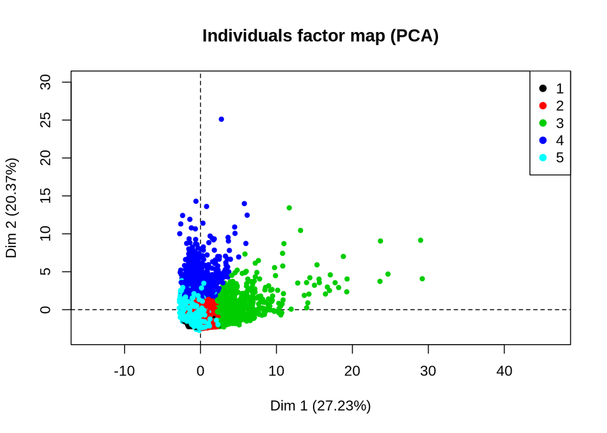

```r
plot(cc_s.pca, choix=c("ind"), label="none", col.ind=cc2$clust)
legend("topright", levels(cc2$clust), pch=19, col=1:5)
```

Hasil yang dihasilkan proses clustering, mirip dengan hipotesa penulis, secara statistik, nilai k yang bagus ada di nilai sekitar 8, namun belum tentu secara bisnis, penulis merasa nilai k=5 lebih cocok untuk pendekatan secara bisnis

Hal ini dapat digunakan untuk menentukan jenis product yang akan dibentuk, limit dari kartu dan Promo yang akan ditawarkan kepada nasabah

Selanjutnya akan dilakukan percobaan dengan melakukan PCA terlebih ahulu kepada data, sebagai metode untuk preprocessing, lalu dilakukan clustering menggunakan k-means dengan parameter yang sama dengan percobaan sebelumnya

# Percobaan K-means dengan menggunakan PCA sebagai metode Pre Process

## Melakukan Pengecekan Hasil PCA

```r
summary(cc_s.pca)
```

```
##
## Call:
## PCA(X = cc_s, graph = F)
##
##
## Eigenvalues
##                        Dim.1   Dim.2   Dim.3   Dim.4   Dim.5   Dim.6
## Variance               4.629   3.464   1.516   1.288   1.067   0.971
## % of var.             27.231  20.374   8.918   7.574   6.277   5.713
## Cumulative % of var.  27.231  47.605  56.524  64.097  70.374  76.087
##                        Dim.7   Dim.8   Dim.9  Dim.10  Dim.11  Dim.12
## Variance               0.836   0.716   0.626   0.524   0.402   0.302
## % of var.              4.916   4.211   3.682   3.082   2.364   1.775
## Cumulative % of var.  81.003  85.214  88.895  91.977  94.341  96.115
##                       Dim.13  Dim.14  Dim.15  Dim.16  Dim.17
## Variance               0.243   0.200   0.171   0.046   0.000
## % of var.              1.427   1.179   1.008   0.271   0.000
## Cumulative % of var.  97.542  98.721  99.729 100.000 100.000
##
## Individuals (the 10 first)
##                                      Dist    Dim.1    ctr   cos2    Dim.2
## 1                                |  2.388 | -1.696  0.007  0.505 | -1.123
## 2                                |  3.543 | -1.216  0.004  0.118 |  2.436
## 3                                |  3.506 |  0.936  0.002  0.071 | -0.385
## 5                                |  2.389 | -1.615  0.007  0.457 | -0.725
## 6                                |  2.179 |  0.224  0.000  0.011 | -0.784
## 7                                |  7.265 |  6.266  0.098  0.744 | -0.609
## 8                                |  2.629 |  0.262  0.000  0.010 | -1.296
## 9                                |  1.721 | -0.465  0.001  0.073 | -0.478
## 10                               |  3.176 | -0.600  0.001  0.036 | -0.409
## 11                               |  2.793 |  0.523  0.001  0.035 | -1.312
##                                     ctr   cos2    Dim.3    ctr   cos2
## 1                                 0.004  0.221 | -0.492  0.002  0.042 |
## 2                                 0.020  0.472 | -0.695  0.004  0.038 |
## 3                                 0.000  0.012 |  0.026  0.000  0.000 |
## 5                                 0.002  0.092 | -0.272  0.001  0.013 |
## 6                                 0.002  0.129 |  1.184  0.011  0.295 |
## 7                                 0.001  0.007 | -2.086  0.033  0.082 |
## 8                                 0.006  0.243 |  1.825  0.025  0.482 |
## 9                                 0.001  0.077 | -0.097  0.000  0.003 |
```

[output cut: 11 more lines]

```
## PURCHASES_FREQUENCY              |  0.696 10.476  0.485 | -0.347  3.481
## ONEOFF_PURCHASES_FREQUENCY       |  0.634  8.688  0.402 | -0.027  0.022
## PURCHASES_INSTALLMENTS_FREQUENCY |  0.596  7.685  0.356 | -0.323  3.013
## CASH_ADVANCE_FREQUENCY           | -0.213  0.983  0.046 |  0.800 18.490
##                                    cos2    Dim.3    ctr   cos2
## BALANCE                           0.571 |  0.214  3.033  0.046 |
## BALANCE_FREQUENCY                 0.057 |  0.565 21.055  0.319 |
## PURCHASES                         0.008 | -0.299  5.885  0.089 |
## ONEOFF_PURCHASES                  0.017 | -0.454 13.585  0.206 |
## INSTALLMENTS_PURCHASES            0.000 |  0.128  1.076  0.016 |
## CASH_ADVANCE                      0.662 |  0.002  0.000  0.000 |
## PURCHASES_FREQUENCY               0.121 |  0.438 12.656  0.192 |
## ONEOFF_PURCHASES_FREQUENCY        0.001 | -0.129  1.097  0.017 |
## PURCHASES_INSTALLMENTS_FREQUENCY  0.104 |  0.554 20.245  0.307 |
## CASH_ADVANCE_FREQUENCY            0.640 |  0.108  0.768  0.012 |
```

```r
cc_s.pcax <- cc_s.pca$call$X[,1:16]
set.seed(30)
clus_cc2 <- kmeans(cc_s.pca$call$X, 8)
```

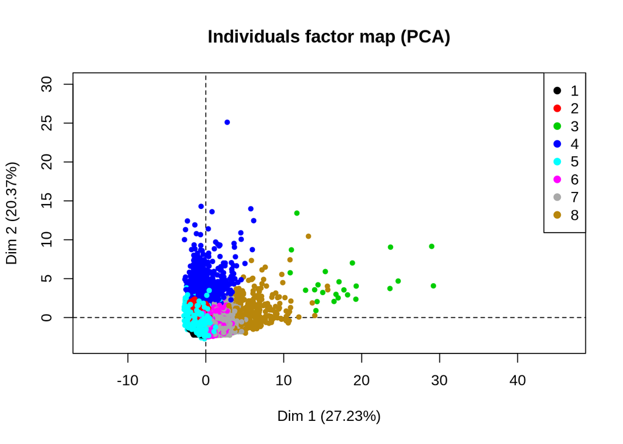

```r
cc3<-cc2
cc3$clust <- as.factor(clus_cc2$cluster)
plot(cc_s.pca, choix=c("ind"), label="none", col.ind=cc3$clust)
legend("topright", levels(cc3$clust), pch=19, col=1:8)
```

Secara hasil tidak dapat dilihat perbedaan nya dengan tanpa pre processing PCA, akan dilihat untuk nilai WSSnya untuk beberapa nilai K

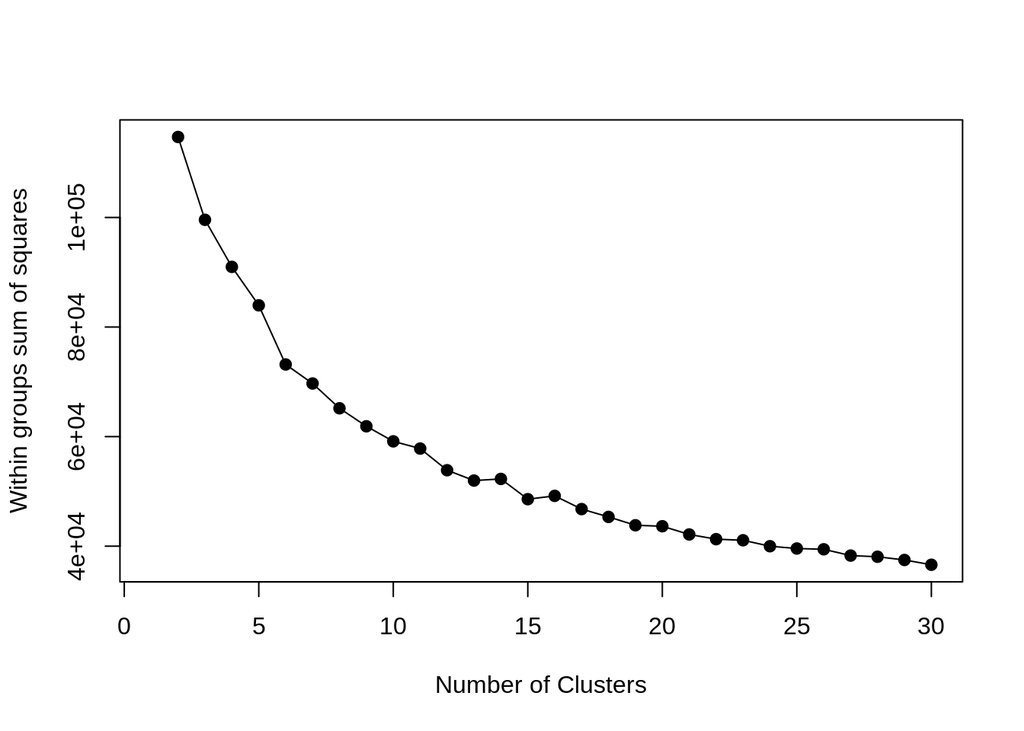

```r
wss(cc_s.pcax)
```

Secara nilai WSS juga tidak dapat dilihat perbedaan yang signifikan